# RNN and LSTM

Kachun Huang

2025-04-29

# RNN and LSTM

## Import Library

```r
library(keras)
library(tensorflow)
library(reticulate)
library(tidyverse)
library(tidyquant)
library(zoo)
library(caret)
library(tidyquant)
library(magrittr)
```

## Data Pre-processing

Before building models, raw data often requires transformation. Common pre-processing steps include:

### **Normalization**

To stabilize model learning, normalize features such as stock prices using min-max scaling:

```r
data$min_lagged <- lag(data$Low)
data$max_lagged <- lag(data$High)
data$Close_norm <- (data$Close - data$min_lagged) / (data$max_lagged - data$min_lagged)
```

### **Handling Missing Values**

```r
data <- na.omit(data)
```

### Date Conversion (Optional)

```r
data$Date <- as.Date(data$Date)
```

### Train-Test Splitting

Split your data into training and test sets to evaluate your model’s generalization performance:

```r
split_index <- floor(0.9 * length(series))
train_data <- series[1:split_index]
test_data <- series[(split_index + 1):length(series)]
```

- `length(series)` returns the total number of time steps in your dataset.
- `floor(0.9 * length(series))` calculates an index at 90% of the data.
- `train_data` selects the first 90% as the training set.
- `test_data` selects the remaining 10% as the test set.

### Creating Time Series Datasets

```r
create_dataset <- function(series, timesteps = 10) {
  x <- list()
  y <- c()
  for (i in 1:(length(series) - timesteps)) {
    x[[i]] <- series[i:(i + timesteps - 1)]
    y <- c(y, series[i + timesteps])
  }
  x_array <- do.call(rbind, x)
  return(list(x = x_array, y = y))
}
```

This prepares the data in a format compatible with RNNs and LSTMs.

Then apply the `create_dataset()` function:

```r
train_set <- create_dataset(train_data, timesteps)
test_set <- create_dataset(test_data, timesteps)
```

Then split `train_set` to `x_train`, `y_train` and convert it to tensor

```r
#convert to array
x_train_array <- array(as.numeric(train_set$x), dim = c(nrow(train_set$x), timesteps, 1))
y_train_array <- as.numeric(train_set$y)

# Convert to TensorFlow tensors
x_train <- tf$convert_to_tensor(x_train_array, dtype = "float32")
y_train <- tf$convert_to_tensor(y_train_array, dtype = "float32")
```

## RNN Model Building

```r
input_rnn <- layer_input(shape = c(timesteps, 1))

output_rnn <- input_rnn %>%
  layer_simple_rnn(units = 32) %>%
  layer_dense(units = 1)

model_rnn <- keras_model(inputs = input_rnn, outputs = output_rnn)
```

## LSTM Model Building

```r
input_lstm <- layer_input(shape = c(timesteps, 1))

output_lstm <- input_lstm %>%
  layer_lstm(units = 32) %>%
  layer_dense(units = 1)

model_lstm <- keras_model(inputs = input_lstm, outputs = output_lstm)
```

These models can be used for sequence-to-one prediction problems.

## **Compilation and Training**

```r
model$compile(
  optimizer = optimizer_adam(),
  loss = "mean_squared_error"
)

history <- model$fit(
  x = x_train,
  y = y_train,
  epochs = r_to_py(100L),
  batch_size = r_to_py(16L),
  verbose = 0
)
```

`r_to_py()` ensures integers are converted correctly for Python-based TensorFlow backend.

## Prediction

```r
predict_next <- function(model, input_seq_array, n_steps = 10) {
  preds <- c() # empty vector to store prediction
  current_input <- input_seq_array
  for (i in 1:n_steps) {
    pred <- model$predict(current_input)
    preds <- c(preds, as.numeric(pred))
    updated_seq <- c(as.numeric(current_input)[-1], as.numeric(pred))
    current_input <- array(updated_seq, dim = c(1, timesteps, 1))
    current_input <- tf$convert_to_tensor(current_input, dtype = "float32")
  }
  return(preds)
}
```

This function generates `n_steps` future predictions based on a rolling window.

### Rescaling Predictions

If you used normalization, reverse it using the original min and max values:

```r
rescaled_value <- norm_value * (original_max - original_min) + original_min
```

## Model Performance

```r
mse <- mean((predicted - actual)^2)
```

## Visualizing Predictions

```r
plot(1:length(actual), actual, type = 'l', col = 'black')
lines(1:length(predicted), predicted, col = 'red')
legend("topright", legend = c("Actual", "Predicted"), col = c("black", "red"), lwd = 2)
```

# Example: sin Curve

Generate a sine wave with the function sin(x) for x ranging from 0 to 20, resulting in a total of 400 points. Plot the generated sequence.

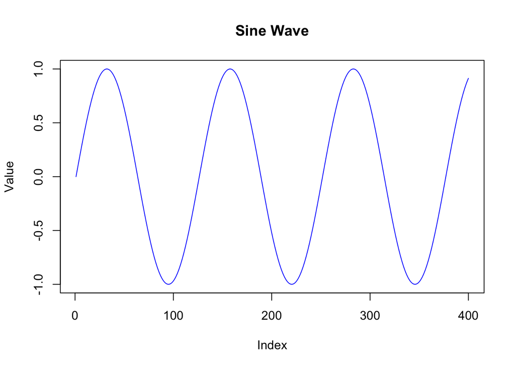

```r
set.seed(123) # set seed

data <- sin(seq(0, 20, length.out = 400)) # create sin data point

# Visualize the sine wave
plot(
  as.vector(data),
  col = 'blue',
  type = 'l',
  ylab = "Value",
  main ="Sine Wave"
)
```

Divide the cleaned dataset into two parts, the **last 10 points for testing y** and **the rest for training**.

```r
length(data)
```

```
## [1] 400
```

```r
train_data <- data[1:(length(data)-10)]
test_data <- data[(length(data)-9):length(data)]
```

prepares the data in a format compatible with RNNs and LSTMs.

```r
create_dataset <- function(series, timesteps = 10) {
  x <- list()
  y <- c()
  for (i in 1:(length(series) - timesteps)) {
    x[[i]] <- series[i:(i + timesteps - 1)]
    y <- c(y, series[i + timesteps])
  }
  x_array <- do.call(rbind, x)
  return(list(x = x_array, y = y))
}
```

Create Training Set

```r
timesteps <- 10
train_set <- create_dataset(train_data, timesteps)
```

Convert to Tensor

```r
#convert to array
x_train_array <- array(as.numeric(train_set$x), dim = c(nrow(train_set$x), timesteps, 1))
y_train_array <- as.numeric(train_set$y)

# Convert to TensorFlow tensors
x_train <- tf$convert_to_tensor(x_train_array, dtype = "float32")
y_train <- tf$convert_to_tensor(y_train_array, dtype = "float32")
```

Please first build RNN with length of sequence 10 using the training data and the RNN method  
with only one RNN layer with 32 hidden units, and the loss function of ‘mse’. You will need to  
create sequences that the RNN can use to learn the pattern. Each input sequence should use 10  
sequential points to predict the next point.

```r
input_rnn <- layer_input(shape = c(timesteps, 1))

output_rnn <- input_rnn %>%
  layer_simple_rnn(units = 32) %>%
  layer_dense(units = 1)

model_rnn <- keras_model(inputs = input_rnn, outputs = output_rnn)

model_rnn$compile(
  optimizer = optimizer_adam(),
  loss = "mean_squared_error"
)
```

Please first build LSTM with length of sequence 10 using the training data and the LSTM method  
with only one LSTM layer with 32 hidden units, and the loss function of ‘mse’. You will need to  
create sequences that the RNN can use to learn the pattern. Each input sequence should use 10  
sequential points to predict the next point.

```r
input_lstm <- layer_input(shape = c(timesteps, 1))

output_lstm <- input_lstm %>%
  layer_lstm(units = 32) %>%
  layer_dense(units = 1)

model_lstm <- keras_model(inputs = input_lstm, outputs = output_lstm)

model_lstm$compile(
optimizer = optimizer_adam(),
loss = "mean_squared_error"
)
```

Plot the training loss for RNN and LSTM.

```r
history_rnn <- model_rnn$fit(
  x = x_train,
  y = y_train,
  epochs = r_to_py(100L),
  batch_size = r_to_py(16L),
  verbose = 0
)

history_lstm <- model_lstm$fit(
x = x_train,
y = y_train,
epochs = r_to_py(100L),
batch_size = r_to_py(16L),
verbose = 0
)
```

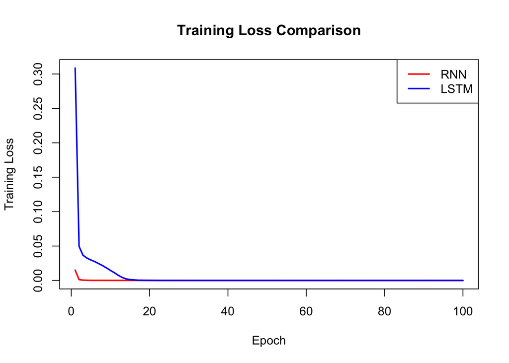

```r
plot(
  history_rnn$history$loss,
  type = 'l',
  col = 'red',
  lwd = 2,
  ylim = range(c(
    history_rnn$history$loss,
    history_lstm$history$loss)
    ),
  xlab = "Epoch",
  ylab = "Training Loss",
  main = "Training Loss Comparison"
)

lines(
  history_lstm$history$loss,
  col = 'blue',
  lwd = 2
)

legend(
  "topright",
  legend = c("RNN", "LSTM"),
  col = c("red", "blue"),
  lwd = 2
)
```

```r
# Predictions
input_seq <- data[381:390]

input_seq_array <- array(
  as.numeric(input_seq),
  dim = c(1, timesteps,1)
)

input_seq_array <- tf$convert_to_tensor(
  input_seq_array,
  dtype = "float32"
)

predict_next <- function(model, input_seq_array, n_steps = 10) {
  preds <- c()
  current_input <- input_seq_array

  for (i in 1:n_steps) {
    pred <- model$predict(current_input)
    preds <- c(preds, as.numeric(pred))
    updated_seq <- c(as.numeric(current_input)[-1], as.numeric(pred))
    current_input <- array(updated_seq, dim = c(1, timesteps, 1))
    current_input <- tf$convert_to_tensor(current_input, dtype = "float32")
  }

  return(preds)
}
```

```r
# 10-step prediction
rnn_preds <- predict_next(
  model_rnn,
  input_seq_array,
  n_steps = 10
)
```

[output not shown]

```r
lstm_preds <- predict_next(
  model_lstm,
  input_seq_array,
  n_steps = 10
)
```

[output not shown]

### Comparison

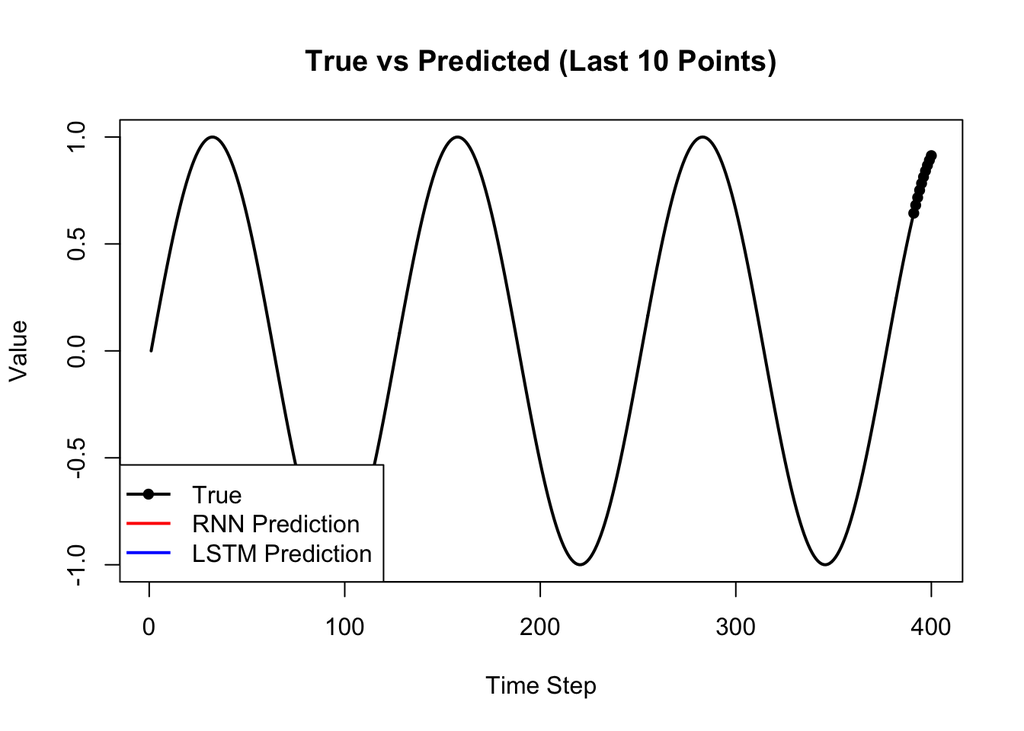

```r
plot(
  1:400,
  data,
  type = 'l',
  col = 'black',
  lwd = 2,
  ylab = "Value",
  xlab = "Time Step",
  main = "True vs Predicted (Last 10 Points)"
)

lines(
  391:400,
  rnn_preds,
  col = 'red',
  lwd = 2
)

lines(
  391:400,
  lstm_preds,
  col = 'blue',
  lwd = 2
)

points(
  391:400,
  test_data,
  col = 'black',
  pch = 16
)

legend(
  "bottomleft",
  legend = c("True", "RNN Prediction", "LSTM Prediction"),
  col = c("black", "red", "blue"),
  lwd = 2,
  pch = c(16, NA, NA)
)
```

# Example: AAPL

```r
data <- read.csv("AAPL.csv")

# transform the data type from 'chr' to 'Date'
data$Date = as.Date(data$Date)

head(data)
```

```
##         Date   Open   High    Low  Close Adj.Close    Volume
## 1 2021-03-29 121.65 122.58 120.73 121.39  120.6728  80819200
## 2 2021-03-30 120.11 120.40 118.86 119.90  119.1916  85671900
## 3 2021-03-31 121.65 123.52 121.15 122.15  121.4283 118323800
## 4 2021-04-01 123.66 124.18 122.49 123.00  122.2733  75089100
## 5 2021-04-05 123.87 126.16 123.07 125.90  125.1561  88651200
## 6 2021-04-06 126.50 127.13 125.65 126.21  125.4643  80171300
```

Plot the close price vs. date to visualize the data we will analyze.

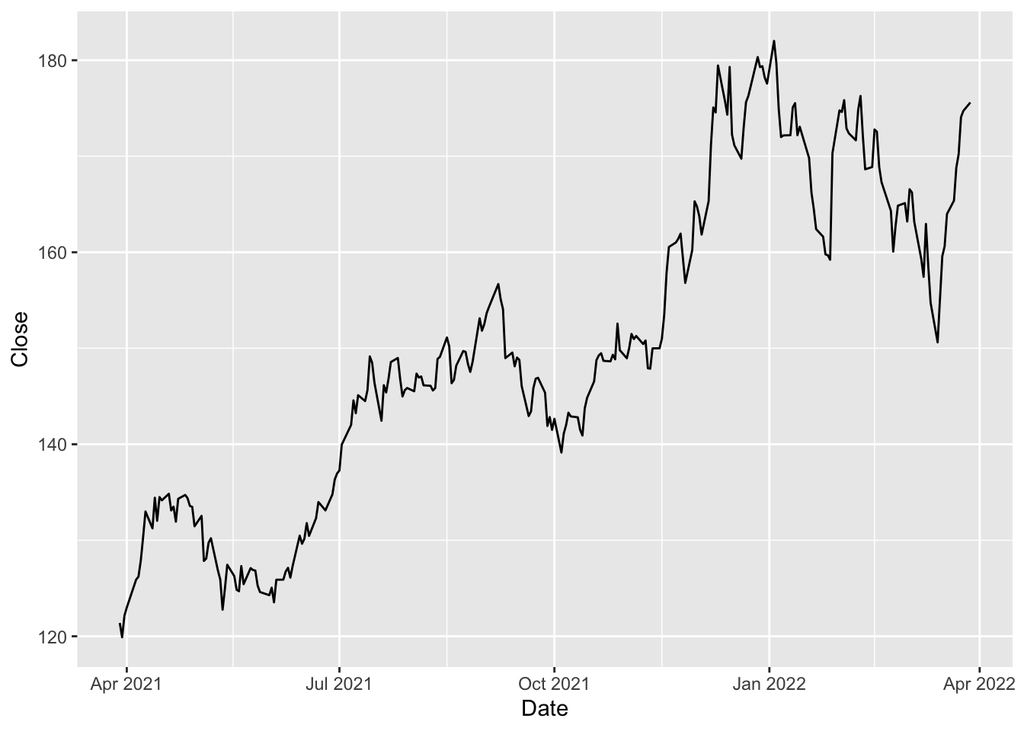

```r
ggplot(
  data,
  aes(x=Date, y = Close)
) + geom_line()
```

Then, use the ‘min-max scaler’ to normalize our stock price data.

Scaled_x = (x-lagged_min(x))/(lagged_max(x) – lagged_min(x)).

```r
data$min_lagged = lag(data$Low)
data$max_lagged = lag(data$High)

data$Close_norm = (data$Close - data$min_lagged) / (data$max_lagged -data$min_lagged)
```

```r
model_data <- matrix(
  data$Close_norm[-1] #excluding volume
)
```

```r
set.seed(123)

# Create sliding window dataset
create_dataset <- function(series, timesteps = 10) {
  x <- list()
  y <- c()
  for (i in 1:(length(series) - timesteps)) {
  x[[i]] <- series[i:(i + timesteps - 1)]
  y <- c(y, series[i + timesteps])
  }
  x_array <- do.call(rbind, x)
  return(list(x = x_array, y = y))
}

# Prepare training data
timesteps <- 10

train_data <- model_data[1:(length(model_data)-10)] # training = all except last 10 days

test_data <- model_data[(length(model_data)-9):length(model_data)] # true last 10 points

train_set <- create_dataset(train_data, timesteps)

x_train_array <- array(
  as.numeric(train_set$x),
  dim = c(nrow(train_set$x), timesteps, 1)
)

y_train_array <- as.numeric(train_set$y)

x_train <- tf$convert_to_tensor(
  x_train_array,
  dtype = "float32"
)

y_train <- tf$convert_to_tensor(
  y_train_array,
  dtype = "float32"
)
```

```r
# Build RNN Model
input_rnn <- layer_input(shape = c(timesteps, 1))

output_rnn <- input_rnn %>%
  layer_simple_rnn(units = 32) %>%
  layer_dense(units = 1)

model_rnn <- keras_model(inputs = input_rnn, outputs = output_rnn)

model_rnn$compile(
  optimizer = optimizer_adam(),
  loss = "mean_squared_error"
)

history_rnn <- model_rnn$fit(
  x = x_train,
  y = y_train,
  epochs = r_to_py(100L),
  batch_size = r_to_py(16L),
  verbose = 0
)
```

```r
# Build LSTM Model
input_lstm <- layer_input(shape = c(timesteps, 1))

output_lstm <- input_lstm %>%
  layer_lstm(units = 32) %>%
  layer_dense(units = 1)

model_lstm <- keras_model(inputs = input_lstm, outputs = output_lstm)

model_lstm$compile(
  optimizer = optimizer_adam(),
  loss = "mean_squared_error"
)

history_lstm <- model_lstm$fit(
  x = x_train,
  y = y_train,
  epochs = r_to_py(100L),
  batch_size = r_to_py(16L),
  verbose = 0
)
```